# Analysis of damage caused by Storm events on US Population and Property for years 1950-2011

Sathish Duraisamy

January 22, 2015

# Introduction

Storms and other severe weather events can cause both public health and economic problems for communities and municipalities. Many severe events can result in fatalities, injuries, and property damage, and preventing such outcomes to the extent possible is a key concern. This report involves exploring the U.S. National Oceanic and Atmospheric Administration’s (NOAA) storm database. This database tracks characteristics of major storms and weather events in the United States, including when and where they occur, as well as estimates of any fatalities, injuries, and property damage.

# Synopsis

The objective of this report is to collect the data, preprocess (clean up) it and explore the Storm events in US over the period of 1950 to 2011, and thereby to identify the most severe events that cause the most damage to humans and property. We retrieve the data for this task from the National Weather Service Storm Data Documentation. We then look for inconsistent and erraneous data, typical of historically maintained data sources, and transform the dataset into a tidy one. From this and with the associated documentation on the data fields, we plot some exploratory plots/charts to visualy grasp the impact of these storm events on humans and property. Every step is documented along the way in a reproducible manner.

# Data Retrieval and Processing

Historical storm data has been maintained by U.S. National Oceanic and Atmospheric Administration [NOAA](http://www.noaa.gov/) There is also some documentation of the database available. Here you will find how some of the variables are constructed/defined [DFN](http://www.ncdc.noaa.gov/stormevents/)

```r
library(ggplot2)
library(dplyr)
library(R.utils)
library(scales)
library(stringr)
library(reshape2)
library(data.table)
fetch_datafiles_if_not_already <- function() {
    require(R.utils)

    # Lets download the zipFile and extract our inputFile off of it
    inputFile <- "repdata-data-StormData.csv"
    if (!file.exists(inputFile)) {
        bzipFile <- "repdata-data-StormData.csv.bz2"
        if (!file.exists(bzipFile)) {
            bzipUrl <- "https://d396qusza40orc.cloudfront.net/repdata%2Fdata%2FStormData.csv.bz2"
            tryCatch({
                message("Downloading a huge bzip file. Please wait....")
                download.file(bzipUrl, destfile=bzipFile,
                              method="curl", quiet=TRUE)

                # Display the downloaded data
                download_date <- Sys.Date()
                download_date
            }, error = function(cond) {
                stop(paste("Error dowloading bzipFile: ", bzipFile,
                           ". Reason: ", cond))
            })
        }

        tryCatch({
            bunzip2(bzipFile)  # Unzip to current working dir
        }, error = function(cond) {
            stop(paste("Error extracting bzipFile: ", bzipFile,
                       ". Reason: ", cond))
        })
    }
}


read_storm_data_efficient <- function() {
    require(data.table)

    fetch_datafiles_if_not_already()

    # dfSD must be defined in the caller's scope for efficiency
    if (is.null(SD)) {
        inputFile <- "repdata-data-StormData.csv"
        message("Loading huge data file 'StormData'. Please be patient!")
        SD <<- read.csv("repdata-data-StormData.csv", header=TRUE,
                       nrow=1240000, sep=",", comment.char="",
                       stringsAsFactors=FALSE)

        # Show the number of rows and columns of our data
        # just after datafile is read
        dim(SD)

        preprocess_data()
    }
}
```

## Data Pre-Processing / Cleanup

The events in the database start in the year 1950 and end in November 2011. In the earlier years of the database there are generally fewer events recorded, most likely due to a lack of good records. More recent years should be considered more complete. We see that the EVTYPE column helps us differentiate various events but this is a free form text field probably human input that has various sorts of data integrity issues ranging from spelling mistakes to empty values to nonsensical values such as LIGHTNING vs LIGHNTING to ‘APACHE TERRITORY’ to " " (empty strings). This results in too many classifications (~840) whereas the associated documentation suggestes only around ~50 classifications. We perform a sequence of the cleaning operations to consolidate(reduce) this variable from ~840 values to ~45 values.

```r
# Crop damage and Property Damage columns have another column associated
# them that give the exponent (10 to the power) for the value
# We need to combine those pairs of columsn
exponent_code_to_value <- function(e) {
    ifelse(e=='H', 100,
               ifelse(e=='T' | e == 'K', 1000,
                      ifelse(e=='M', 10^6,
                             ifelse(e=='B', 10^9, 1))))
}


preprocess_data <- function() {
    # Take only these columns and throw away the rest
    # BGN_DATE, STATE, EVTYPE, FATALITIES, INJURIES,
    # PROPDMG, PROPDMGEXP, CROPDMG, CROPDMGEXP
    requiredCols <- c(2, 7, 8, 23:28)
    SD <<- SD[,requiredCols]

    # Consistent lower-case variable(column) names
    names(SD) <<- tolower(names(SD))

    # The EVTYPE variable has many human error characteristics
    # typical of free form text input. Lets apply a series of
    # transformations to that column
    SD$evtype.orig <<- SD$evtype

    SD$evtype <<- sanitize_event_type(SD$evtype)

    # Crop damage and Property Damage columns have another column associated
    # them that give the exponent (10 to the power) for the value
    # We need to combine those pairs of columsn
    ok <- complete.cases(SD$cropdmg, SD$cropdmgexp)
    SD$cropdmg[ok] <<- SD$cropdmg[ok] * exponent_code_to_value(toupper(SD$cropdmgexp[ok]))
    ok <- complete.cases(SD$propdmg, SD$propdmgexp)
    SD$propdmg[ok] <<- SD$propdmg[ok] * exponent_code_to_value(toupper(SD$propdmgexp[ok]))

    #Just after preprocessing, display the number of rows & cols, col-names
    dim(SD)
    names(SD)
}
```

The pre-processing step involves reducing the multiple storm type string values into few manageable and consistent values.

- First we convert the evtype values to a consistent uppercase and trim the leading and trailing spaced. So a value " Heavy Wind / High Surf " becomes “HEAVY WIND / HIGH SURF”
- Then we replace each non-word character (that is not an alphabet or digit or underscore) with a single space and a sequence of spaces with a single space as well.. “HEAVY WIND / HIGH SURF” becomes “HEAVY WIND HIGH SURF”
- Remove observations with human data entry errors. We can’t classify them anyway.
- Then apply a series of regular expression match and replacements to reduce the ~840 possibilities into ~40 possibilities.

```r
sanitize_event_type <- function(evtype) {
    # First, upper-case, trim leading and training whitespace
    evtype <- str_trim(toupper(evtype))

    # Replace non-word chars with a single space. Multiple spaces into one space
    evtype <- gsub("\\W+", " ", evtype)
    evtype <- gsub("\\s+", " ", evtype)

    # Human errors; can't classify them
    evtype <- gsub("^(SUMMARY|MONTHLY|NO |NONE|SEI|APACHE|SOUTH|\\s+).*",
                   NA, evtype)

    # Apply these pattern replacements to reduce the ~900 unique possibilities
    # into a manageable ~40 possible classifications.
    pat <- c(
        #----------------------------
        #"pattern","replacement"
        #----------------------------
        "^RECORD\\s*HIGH", "HIGH",
        "^RECORD\\s*LOW", "LOW",
        "^(RECORD|EXCESSIVE)", "HIGH",
        "^AVALAN.*", "Avalanche",
        "^BEACH ERO.*", "Beach Erosion",
        ".*BLIZZAR.*", "Blizzard",
        "^BLOWING SNOW.*", "Blowing Snow",
        "^COASTAL.*FLO.*", "Coastal Flood",
        "^COASTAL.*STO.*", "Coastal Storm",
        ".*(COLD|ICE|ICY|WET|WINT|FREEZ|CHILL|COOL).*", "Cold",
        ".*(THUNDER.*ST|TSTM).*", "Thunderstorm",
        "^DUST.*(DEV|STO).*", "Dust Storm",
        "^EXTRE.*COLD.*", "Extream Cold",
        ".*(FLASH.*FLOO|URB.*STR).*", "Flash Flood",
        ".*(FLOOD|SMALL\\s*STR).*", "Flood",
        "^URBAN.*FLOOD.*", "Flood",
        "^FREEZ.*RAIN.*", "Freezing Rain",
        "^HAIL.*", "Hail Storm",
        "^HEAVY.*(RAIN|SHOWER).*", "Heavy Rain",
        "^HEAVY.*SNOW.*", "Heavy Snow",
        "^HIGH.*WIND.*", "High Wind",
        "^HIGH.*SURF.*", "High Surf",
        "^HURRICANE.*", "Hurrycane",
        "^HYP(O|ER)TH.*", "Hypothermia",
        "^(ICE|ICY).*STOR.*", "Icy Storm",
        "^LIGHTNING.*", "Lightning",
        "^LIGHT.*SNOW.*", "Light Snow",
        ".*(LAND|MUD).*(SLIDE|SLUMP).*", "Land Slide",
        "^RAIN.*", "Rain",
        "^SNOW.*", "Snow",
        "^TIDAL.*FLOO.*", "Tidal Flood",
        ".*(FLOOD|FLD).*", "Flood",
        "^TORN(ADO|DAO).*", "Tornado",
        "^TROPICAL.*STORM.*", "Tropical Storm",
        "^VOLCAN.*ERUP.*", "Volcanic Eruption",
        "^VOLCAN.*ASH.*", "Volcanic Ash",
        "^WATER.*SPOU.*", "Water Spout",
        ".*WIND CHILL.*", "Wind Chill",
        "^WIND.*", "Wind",
        "^WINTER.*STOR.*", "Winter Storm",
        ".*UNSEASON.*", "Unseasonable Weather",
        ".*(SWELL|WAVE|WATER|SURF|COASTAL|TIDE|SEA|MARINE).*", "Heavy Tide",
        ".*(WIND|WND|GUST|DUST).*", "Wind",
        ".*SNOW.*", "Heavy Snow",
        ".*(FIRE|SMOKE).*", "Fire",
        ".*(DRY|WARM|HEAT|HOT|DRIEST|DROUGHT).*", "Heat",
        ".*FOG.*", "Fog",
        ".*(FUNNEL|CLOUD).*", "Cloud",
        ".*(RAIN|PRECIP).*", "Heavy Rain",
        ".*HAIL.*", "Hail",
        ".*LIG.*ING.*", "Lightning",
        ".*HIGH.*TEMP.*", "Heat",
        ".*(FROST|LOW.*TEMP).*", "Cold",
        ".*SLIDE.*", "Landslide",
        ".*TSUNA.*", "Tsunami",
        ".*TYPHOO.*", "Typhoon",
        ".*SPOUT.*", "Water Spout",
        ".*DROWN.*", "Drowning",
        ".*URBAN.*SMALL.*", "Flash Flood",
        ".*DAM\\s+.*", "Dam Failure",
        "^[A-Z][A-Z]+.*", "Other"  # Put evertying else in 'Other' bucket
    )
    for (r in seq(1, length(pat), 2)) {
        pattern <- pat[r]; replacement <- pat[r+1];
        evtype <- gsub(pattern, replacement, x=evtype)
    }
    evtype
}
```

Now, we read the data and make the first level of counts per each event type total fatalities, total injuries, total property damages and total crop damages.

```r
SD <- NULL
read_storm_data_efficient()
```

```
## Loading huge data file 'StormData'. Please be patient!
```

```
##  [1] "bgn_date"    "state"       "evtype"      "fatalities"  "injuries"
##  [6] "propdmg"     "propdmgexp"  "cropdmg"     "cropdmgexp"  "evtype.orig"
```

```r
# Get totals of fatality, injury, cropdmg, propdmg, per each unique event
df <- SD %>%
        group_by(evtype) %>%
        summarise(tot_fatal = sum(fatalities),
                  tot_injur = sum(injuries),
                  tot_propdmg = sum(propdmg),
                  tot_cropdmg = sum(cropdmg))
```

# Question #1: Which events are the most harmful to Public Health/Life ?

```r
    dfh <- df %>%
            filter(tot_fatal > 0 | tot_injur > 0) %>%
            arrange(tot_fatal)
    y_scale <- seq_along(1:NROW(dfh))
    dfh <- dfh %>% mutate(evtype_f = factor(y_scale, levels=y_scale, labels=evtype))

    dfh # This is the final contents of our Tidy data, just before plotting
```

```
## Source: local data frame [37 x 6]
##
##                  evtype tot_fatal tot_injur  tot_propdmg tot_cropdmg
## 1                 Cloud         0         3       194600           0
## 2                  Hail         0        10        70000    20793000
## 3               Typhoon         0         5    600230000      825000
## 4              Drowning         1         0            0           0
## 5            Light Snow         1         2      2598000           0
## 6          Blowing Snow         2        14        15000           0
## 7         Coastal Storm         4         2        50000           0
## 8                  Rain         5         2      5350050      750000
## 9         Coastal Flood         6         7    427566060       56000
## 10          Water Spout         6        72     60737200           0
## 11                 Snow         8       102     18347550       10000
## 12          Hypothermia         9         0            0           0
```

[output cut: 26 more lines]

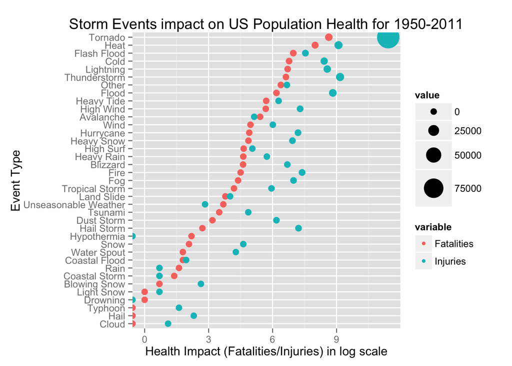

```r
    # Melt a 3 column dataset into a 2 column dataset for easy
    # two series-of-points plotting in the same plot
    df2 <- melt(dfh[,c("evtype_f", "tot_fatal", "tot_injur")], id="evtype_f")
    df2$variable <- gsub("tot_fatal", "Fatalities", df2$variable)
    df2$variable <- gsub("tot_injur", "Injuries", df2$variable)

    ggplot(df2, aes(y=evtype_f, x=log(value), colour=variable, size=value)) +
      geom_point(shape=20) +
      scale_size_continuous(range = c(4,15)) +
      ylab("Event Type") +
      xlab("Health Impact (Fatalities/Injuries) in log scale") +
      ggtitle("Storm Events impact on US Population Health for 1950-2011")
```

# Result #1

[output not shown]

```r
  # Top most 5 severe events
  head(arrange(dfh, -tot_fatal)[,c(1,2,3)], 5)
```

```
## Source: local data frame [5 x 3]
##
##        evtype tot_fatal tot_injur
## 1     Tornado      5633     91364
## 2        Heat      2960      8864
## 3 Flash Flood      1064      1879
## 4        Cold       874      4531
## 5   Lightning       817      5231
```

# Question #2: Which events cause the most damage to US Properties/Agriculture ?

```r
    dfp <- df %>%
            filter(complete.cases(evtype, tot_propdmg, tot_cropdmg) &
                       tot_propdmg > 0 | tot_cropdmg > 0) %>%
            arrange(tot_propdmg)
    y_scale <- seq_along(1:NROW(dfp))
    dfp <- dfp %>% mutate(evtype_f = factor(y_scale, levels=y_scale, labels=evtype))

    dfp # This is the final contents of our Tidy data, just before plotting
```

```
## Source: local data frame [39 x 6]
##
##                  evtype tot_fatal tot_injur  tot_propdmg tot_cropdmg
## 1  Unseasonable Weather        40        17            0    10010000
## 2          Blowing Snow         2        14        15000           0
## 3         Coastal Storm         4         2        50000           0
## 4                  Hail         0        10        70000    20793000
## 5         Beach Erosion         0         0       100000           0
## 6             Landslide         0         0       150000           0
## 7                 Cloud         0         3       194600           0
## 8          Volcanic Ash         0         0       500000           0
## 9           Dam Failure         0         0      1002000           0
## 10           Light Snow         1         2      2598000           0
## 11            Avalanche       225       170      3721800           0
## 12                 Rain         5         2      5350050      750000
```

[output cut: 28 more lines]

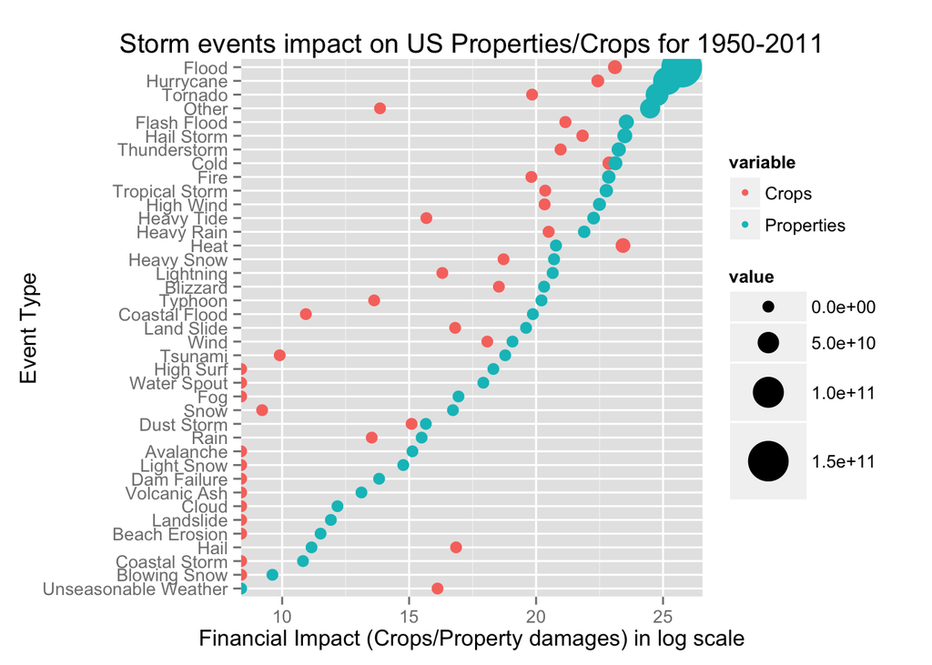

```r
    # Melt a 3 column dataset into a 2 column dataset for easy
    # two series-of-points plotting in the same plot
    df2 <- melt(dfp[,c("evtype_f", "tot_cropdmg", "tot_propdmg")], id="evtype_f")
    df2$variable <- gsub("tot_cropdmg", "Crops", df2$variable)
    df2$variable <- gsub("tot_propdmg", "Properties", df2$variable)

    ggplot(df2, aes(y=evtype_f, x=log(value), colour=variable, size=value)) +
      geom_point(shape=20) +
      scale_size_continuous(range = c(4,15)) +
      ylab("Event Type") +
      xlab("Financial Impact (Crops/Property damages) in log scale") +
      ggtitle("Storm events impact on US Properties/Crops for 1950-2011")
```

# Results #2

[output not shown]

```r
  # Top most 5 severe events
  head(arrange(dfp, -tot_propdmg)[,c(1,4,5)], 5)
```

```
## Source: local data frame [5 x 3]
##
##        evtype  tot_propdmg tot_cropdmg
## 1       Flood 150189663635 10842825950
## 2   Hurrycane  84756180010  5515292800
## 3     Tornado  56941932479   414961470
## 4       Other  43327928500     1039400
## 5 Flash Flood  16964543937  1540685250
```